# Breast Cancer Wisconsin Diagnostic — Exploratory Analysis

Somnath Chaudhuri

November 10, 2025

# Introduction

This short training document shows step-by-step exploratory data analysis (EDA) for the **Breast Cancer Wisconsin (Diagnostic)** dataset.  
The goal is to demonstrate a compact, reproducible workflow with clear interpretations before modeling.

# Data loading and structure

```r
# Load data and column names
breastCancerData <- read_csv(
  "https://archive.ics.uci.edu/ml/machine-learning-databases/breast-cancer-wisconsin/wdbc.data",
  col_names = FALSE
)

breastCancerDataColNames <- read_csv(
  "https://raw.githubusercontent.com/fpsom/2020-07-machine-learning-sib/master/data/wdbc.colnames.csv",
  col_names = FALSE
)

# Check counts match
ncol(breastCancerData)
```

```
## [1] 32
```

```r
nrow(breastCancerDataColNames)
```

```
## [1] 32
```

```r
# Assign names safely
if (nrow(breastCancerDataColNames) == ncol(breastCancerData)) {
  colnames(breastCancerData) <- breastCancerDataColNames$X1
} else {
  stop("Column name count does not match data columns. Please verify column source.")
}

# Clean column names for safe reference
colnames(breastCancerData) <- make.names(colnames(breastCancerData))

# Convert diagnosis to factor
breastCancerData$Diagnosis <- as.factor(breastCancerData$Diagnosis)

# Remove first column
breastCancerData <- breastCancerData[2:ncol(breastCancerData)]

# Quick checks
dim(breastCancerData)
```

```
## [1] 569  31
```

```r
names(breastCancerData)
```

```
##  [1] "Diagnosis"               "Radius.Mean"
##  [3] "Texture.Mean"            "Perimeter.Mean"
##  [5] "Area.Mean"               "Smoothness.Mean"
##  [7] "Compactness.Mean"        "Concavity.Mean"
##  [9] "Concave.Points.Mean"     "Symmetry.Mean"
## [11] "Fractal.Dimension.Mean"  "Radius.SE"
## [13] "Texture.SE"              "Perimeter.SE"
## [15] "Area.SE"                 "Smoothness.SE"
## [17] "Compactness.SE"          "Concavity.SE"
## [19] "Concave.Points.SE"       "Symmetry.SE"
## [21] "Fractal.Dimension.SE"    "Radius.Worst"
## [23] "Texture.Worst"           "Perimeter.Worst"
## [25] "Area.Worst"              "Smoothness.Worst"
## [27] "Compactness.Worst"       "Concavity.Worst"
## [29] "Concave.Points.Worst"    "Symmetry.Worst"
## [31] "Fractal.Dimension.Worst"
```

```r
head(breastCancerData)
```

| Diagnosis | Radius.Mean | Texture.Mean | Perimeter.Mean | Area.Mean | Smoothness.Mean | Compactness.Mean | Concavity.Mean | Concave.Points.Mean | Symmetry.Mean | Fractal.Dimension.Mean | Radius.SE | Texture.SE | Perimeter.SE | Area.SE | Smoothness.SE | Compactness.SE | Concavity.SE | Concave.Points.SE | Symmetry.SE | Fractal.Dimension.SE | Radius.Worst | Texture.Worst | Perimeter.Worst | Area.Worst | Smoothness.Worst | Compactness.Worst | Concavity.Worst | Concave.Points.Worst | Symmetry.Worst | … |
| --- | --- | --- | --- | --- | --- | --- | --- | --- | --- | --- | --- | --- | --- | --- | --- | --- | --- | --- | --- | --- | --- | --- | --- | --- | --- | --- | --- | --- | --- | --- |
| M | 17.99 | 10.38 | 122.80 | 1001.0 | 0.11840 | 0.27760 | 0.3001 | 0.14710 | 0.2419 | 0.07871 | 1.0950 | 0.9053 | 8.589 | 153.40 | 0.006399 | 0.04904 | 0.05373 | 0.01587 | 0.03003 | 0.006193 | 25.38 | 17.33 | 184.60 | 2019.0 | 0.1622 | 0.6656 | 0.7119 | 0.2654 | 0.4601 | … |
| M | 20.57 | 17.77 | 132.90 | 1326.0 | 0.08474 | 0.07864 | 0.0869 | 0.07017 | 0.1812 | 0.05667 | 0.5435 | 0.7339 | 3.398 | 74.08 | 0.005225 | 0.01308 | 0.01860 | 0.01340 | 0.01389 | 0.003532 | 24.99 | 23.41 | 158.80 | 1956.0 | 0.1238 | 0.1866 | 0.2416 | 0.1860 | 0.2750 | … |
| M | 19.69 | 21.25 | 130.00 | 1203.0 | 0.10960 | 0.15990 | 0.1974 | 0.12790 | 0.2069 | 0.05999 | 0.7456 | 0.7869 | 4.585 | 94.03 | 0.006150 | 0.04006 | 0.03832 | 0.02058 | 0.02250 | 0.004571 | 23.57 | 25.53 | 152.50 | 1709.0 | 0.1444 | 0.4245 | 0.4504 | 0.2430 | 0.3613 | … |
| M | 11.42 | 20.38 | 77.58 | 386.1 | 0.14250 | 0.28390 | 0.2414 | 0.10520 | 0.2597 | 0.09744 | 0.4956 | 1.1560 | 3.445 | 27.23 | 0.009110 | 0.07458 | 0.05661 | 0.01867 | 0.05963 | 0.009208 | 14.91 | 26.50 | 98.87 | 567.7 | 0.2098 | 0.8663 | 0.6869 | 0.2575 | 0.6638 | … |
| M | 20.29 | 14.34 | 135.10 | 1297.0 | 0.10030 | 0.13280 | 0.1980 | 0.10430 | 0.1809 | 0.05883 | 0.7572 | 0.7813 | 5.438 | 94.44 | 0.011490 | 0.02461 | 0.05688 | 0.01885 | 0.01756 | 0.005115 | 22.54 | 16.67 | 152.20 | 1575.0 | 0.1374 | 0.2050 | 0.4000 | 0.1625 | 0.2364 | … |
| M | 12.45 | 15.70 | 82.57 | 477.1 | 0.12780 | 0.17000 | 0.1578 | 0.08089 | 0.2087 | 0.07613 | 0.3345 | 0.8902 | 2.217 | 27.19 | 0.007510 | 0.03345 | 0.03672 | 0.01137 | 0.02165 | 0.005082 | 15.47 | 23.75 | 103.40 | 741.6 | 0.1791 | 0.5249 | 0.5355 | 0.1741 | 0.3985 | … |

```r
summary(breastCancerData$diagnosis)
```

```
## Length  Class   Mode
##      0   NULL   NULL
```

# Missingness and overview

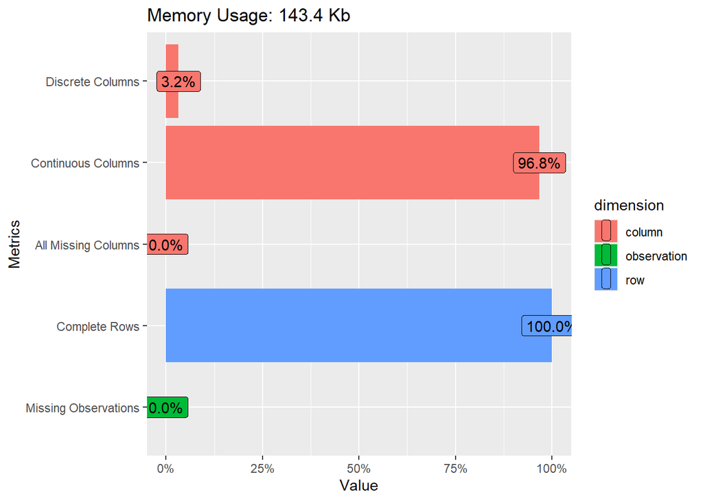

```r
plot_intro(breastCancerData)
```

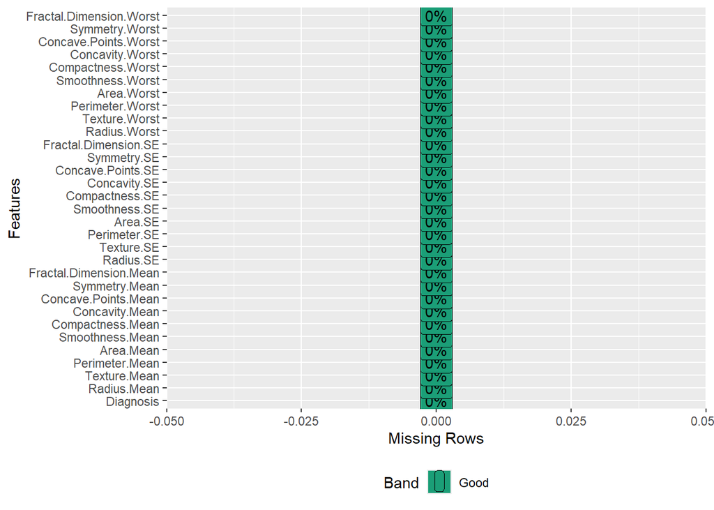

```r
plot_missing(breastCancerData)
```

**Observation:** No missing data — the dataset is complete and balanced for analysis.

# Using first 6 columns of the dataset to explore

```r
breastCancerData <- breastCancerData%>% select(1:6)
# Quick checks
dim(breastCancerData)
```

```
## [1] 569   6
```

```r
names(breastCancerData)
```

```
## [1] "Diagnosis"       "Radius.Mean"     "Texture.Mean"    "Perimeter.Mean"
## [5] "Area.Mean"       "Smoothness.Mean"
```

```r
head(breastCancerData)
```

| Diagnosis | Radius.Mean | Texture.Mean | Perimeter.Mean | Area.Mean | Smoothness.Mean |
| --- | --- | --- | --- | --- | --- |
| M | 17.99 | 10.38 | 122.80 | 1001.0 | 0.11840 |
| M | 20.57 | 17.77 | 132.90 | 1326.0 | 0.08474 |
| M | 19.69 | 21.25 | 130.00 | 1203.0 | 0.10960 |
| M | 11.42 | 20.38 | 77.58 | 386.1 | 0.14250 |
| M | 20.29 | 14.34 | 135.10 | 1297.0 | 0.10030 |
| M | 12.45 | 15.70 | 82.57 | 477.1 | 0.12780 |

# Univariate distributions

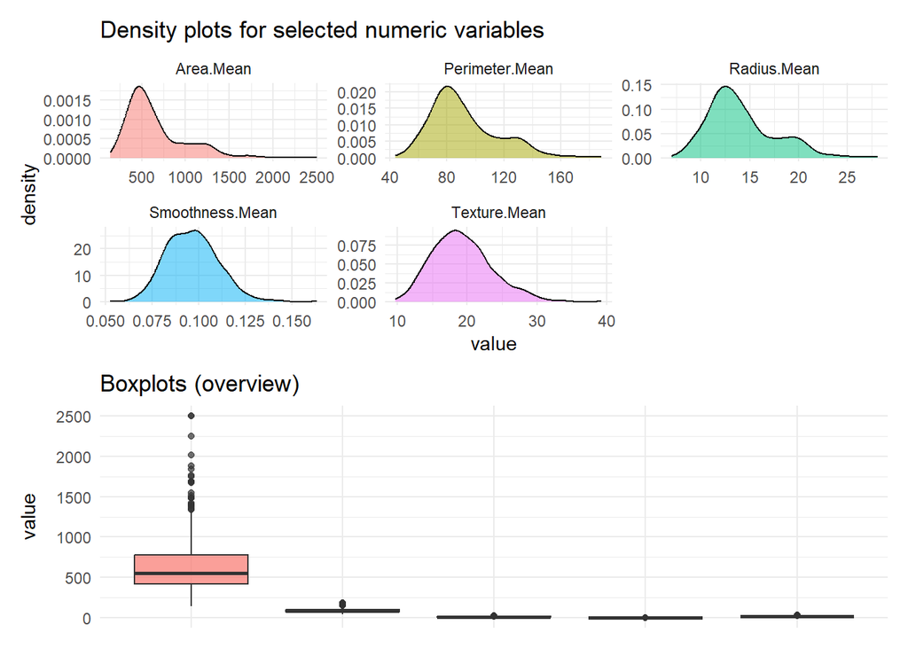

```r
num_cols <- breastCancerData %>% select(where(is.numeric))
long_df <- num_cols %>%
pivot_longer(cols = everything(), names_to = "variable", values_to = "value")

p_density <- ggplot(long_df, aes(x = value, fill = variable)) +
geom_density(alpha = 0.5) +
facet_wrap(~variable, scales = "free", ncol = 3) +
labs(title = "Density plots for selected numeric variables") +
theme_minimal() +
theme(legend.position = "none")

p_box <- ggplot(long_df, aes(x = variable, y = value, fill = variable)) +
geom_boxplot(alpha = 0.7) +
labs(title = "Boxplots (overview)", x = NULL) +
theme_minimal() +
theme(axis.text.x = element_blank(), legend.position = "none")

p_density / p_box
```

**Inference:** Some variables (e.g., radius_mean and area_mean) are right-skewed, suggesting the need for scaling or transformation before modeling.

# Bivariate relationships by diagnosis

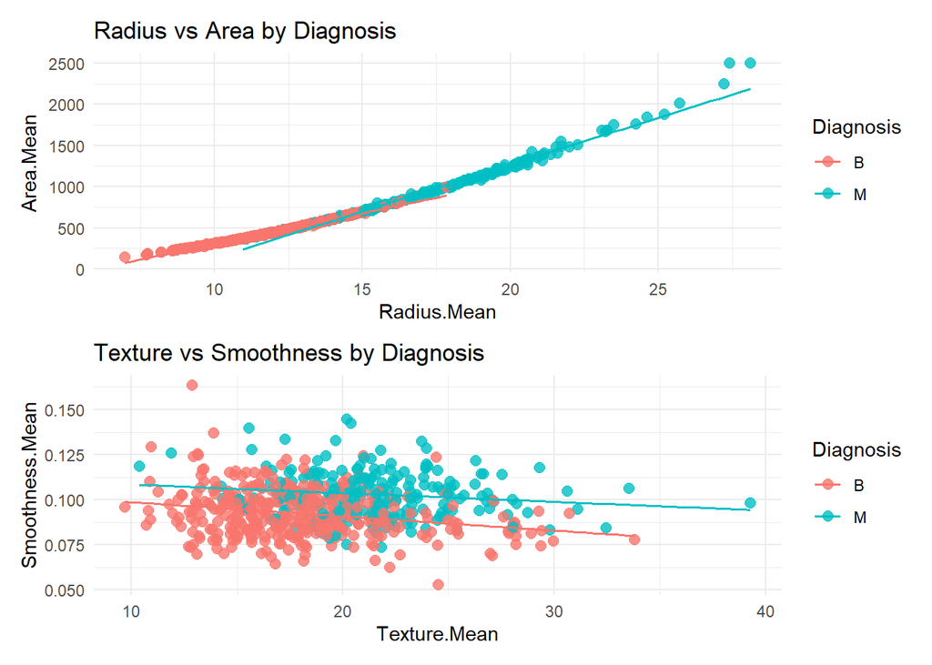

```r
p1 <- ggplot(breastCancerData, aes(x = Radius.Mean, y = Area.Mean, color = Diagnosis)) +
geom_point(size = 2.5, alpha = 0.8) +
geom_smooth(method = "lm", se = FALSE, size = 0.6) +
labs(title = "Radius vs Area by Diagnosis") +
theme_minimal()

p2 <- ggplot(breastCancerData, aes(x = Texture.Mean, y = Smoothness.Mean, color = Diagnosis)) +
geom_point(size = 2.5, alpha = 0.8) +
geom_smooth(method = "lm", se = FALSE, size = 0.6) +
labs(title = "Texture vs Smoothness by Diagnosis") +
theme_minimal()

p1 / p2
```

**Inference:** Malignant tumors tend to have higher radius, area, and texture values. Benign tumors generally have lower measurements and smoother surfaces.

# Distribution by diagnosis (violin plots)

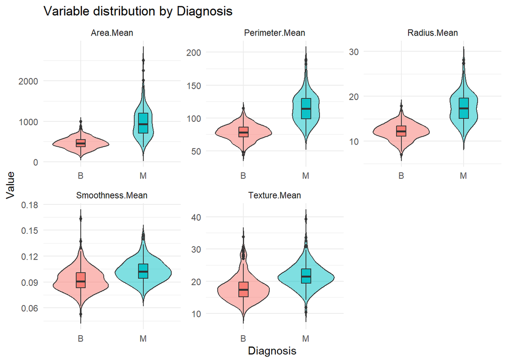

```r
df_long <- breastCancerData %>%
pivot_longer(-Diagnosis, names_to = "variable", values_to = "value")

ggplot(df_long, aes(x = Diagnosis, y = value, fill = Diagnosis)) +
geom_violin(alpha = 0.5, trim = FALSE) +
geom_boxplot(width = 0.15, outlier.size = 1, alpha = 0.9) +
facet_wrap(~variable, scales = "free", ncol = 3) +
labs(title = "Variable distribution by Diagnosis", x = "Diagnosis", y = "Value") +
theme_minimal() +
theme(legend.position = "none")
```

**Inference:** Malignant cases show higher radius, perimeter, area, and texture. Smoothness is slightly higher for malignant tumors.

# Correlation matrix

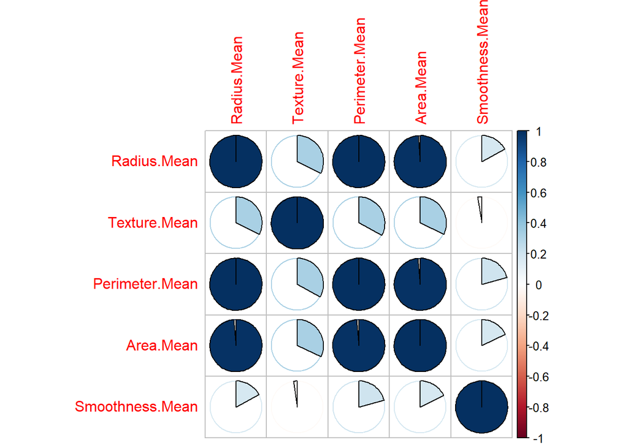

```r
num <- breastCancerData %>% select(where(is.numeric))
M <- cor(num)
corrplot(M, method = "pie")
```

```r
round(M, 2)
```

```
##                 Radius.Mean Texture.Mean Perimeter.Mean Area.Mean
## Radius.Mean            1.00         0.32           1.00      0.99
## Texture.Mean           0.32         1.00           0.33      0.32
## Perimeter.Mean         1.00         0.33           1.00      0.99
## Area.Mean              0.99         0.32           0.99      1.00
## Smoothness.Mean        0.17        -0.02           0.21      0.18
##                 Smoothness.Mean
## Radius.Mean                0.17
## Texture.Mean              -0.02
## Perimeter.Mean             0.21
## Area.Mean                  0.18
## Smoothness.Mean            1.00
```

# Pairwise scatter matrix

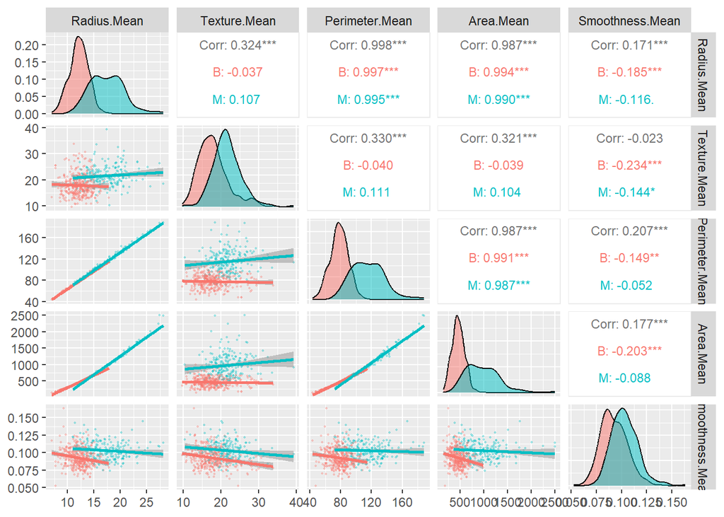

```r
ggpairs(
breastCancerData,
columns = 2:6,
mapping = aes(color = Diagnosis, alpha = 0.6),
upper = list(continuous = wrap("cor", size = 3)),
lower = list(continuous = wrap("smooth", alpha = 0.3, size = 0.4)),
diag = list(continuous = wrap("densityDiag", alpha = 0.5))
)
```

**Inference:** Malignant tumors cluster in the higher ranges for radius, perimeter, and area. Benign tumors occupy lower ranges. Strong correlations exist among size-related features.

# Feature engineering & scaling

```r
# Example: area-to-radius ratio
breastCancerData <- breastCancerData %>%
mutate(area_to_radius = Area.Mean / Radius.Mean)

summary(breastCancerData$area_to_radius)
```

```
##    Min. 1st Qu.  Median    Mean 3rd Qu.    Max.
##   20.56   35.89   41.18   43.58   49.48   91.21
```

```r
# Scale numeric features
scaled_data <- as.data.frame(scale(breastCancerData %>% select(where(is.numeric))))
scaled_data$Diagnosis <- breastCancerData$Diagnosis

head(scaled_data)
```

|  | Radius.Mean | Texture.Mean | Perimeter.Mean | Area.Mean | Smoothness.Mean | area_to_radius | Diagnosis |
| --- | --- | --- | --- | --- | --- | --- | --- |
| 1 | 1.0960995 | -2.0715123 | 1.2688173 | 0.9835095 | 1.5670875 | 1.0805060 | M |
| 2 | 1.8282120 | -0.3533215 | 1.6844726 | 1.9070303 | -0.8262354 | 1.8708871 | M |
| 3 | 1.5784992 | 0.4557859 | 1.5651260 | 1.5575132 | 0.9413821 | 1.5692961 | M |
| 4 | -0.7682333 | 0.2535091 | -0.5921661 | -0.7637917 | 3.2806668 | -0.8758187 | M |
| 5 | 1.7487579 | -1.1508038 | 1.7750113 | 1.8246238 | 0.2801253 | 1.8225280 | M |
| 6 | -0.4759559 | -0.8346009 | -0.3868077 | -0.5052059 | 2.2354545 | -0.4715078 | M |

**Inference:** Derived ratio captures proportionality differences. Scaled data ensures features contribute equally for modeling.

# Pre-modelling checklist

1. Classes moderately balanced between Malignant and Benign.
2. No missing values.
3. High correlations among radius, area, and perimeter — consider dimensionality reduction.
4. Scaling and derived ratios improve comparability across features.